# Credit_portfolio_EDA

Daniel Mogere

2024-07-17

In this markdown file, I conduct some Exploratory Data Analysis on the credit data. I start with univariate analysis and then later explore some cross-tabulations with the outcome variables

**KEY HIGHLIGHTS**

**Findings from Univariate analysis:**

- The data is imbalanced, majority (75%) were customers with fully paid loans, 25% charged off.
- Majority (34%) have an annual income of between 1-1.5M, closely followed by those with an annual income of 500K-1M (31%)
- Majority (35%) have been in their current job for more than 10 years
- Majority (49%) have a Home mortgage, closely followed by those living on rental apartments(42%)
- About 60% of the customers have 10-20 years of credit history, and have a “Good” credit score 670-739(74%).
- 74% of the loans were short term, and the main purpose of the loans was for debt consolidation (79%)
- Majority took out loan amount between 200-500K

**Findings from Statistical Analysis:**

- There is a statistically significant difference between the average current loan amount of the Fully Paid category(288894.4) and the average current loan amount of the Charged off category (324975.2), p=0.
- There are higher odds of a short term loan being fully paid (97% increase in odds) than a long term loan being fully paid (84% increase in odds)
- As the annual income of the customer increases, it does not affect the chance of the loan being fully paid.
- An increase in the current loan amount by 1 unit (shilling) reduces the odds of a loan being fully repaid by about 0.0001%.
- An increase in the montly debt by one unit reduces the odds of a loan being fully paid by 0.0002% chance.
- As the customer’s years of credit history increase by one year, the chances of a loan being fully paid increase by 0.989%
- An increase by 1 unit of credit score, increase the probability of a loan being repaid by 50%
- For a customer who has zero months since they were last deliquent, there is 74% probability that the loan will be fully repaid. As the months since a customer was deliquent increase by 1 month, the probability of a loan being fully paid are 50%.
- For a customer who has zero open accounts, the probability of a loan being fully paid is 76%. When the cutomer’s open account increase by 1 more account, it reduces the probability of a loan being fully paid by 50%.
- When a customer has zero credit problems, there is a 75% probability that the loan will be fully paid. When a customer’s credit problems increase by 1, the probability of the loan being fully repaid reduces by 51%.
- An increase in credit balance, has no effect on the probability of a loan being fully paid. Same case with the maximum open credit.
- When a customer has 0 bankruptcies, the probability if a loan being fully repaid is 74.7%.

-When a customer has zero tax liens, the probability of a loan being fully repaid is 74.8%. When the tax liens increase by 1 unit, the probability of a loan being fully repaid drop by 53%.

**INSIGHTS/Recommendations**

To improve loan portfolio:

Set up and download needed packages

Load the data

```r
data<-read.csv(here("Clean_Data","credit_train_final_clean_v1.csv"))

#drop unnecessary variable of Loain Id and customer id to enhance performance
cols_to_drop<-c("Loan.ID","Customer.ID")
data<- data%>%
  select(!cols_to_drop)
```

First, explore the overall split of the Loan status

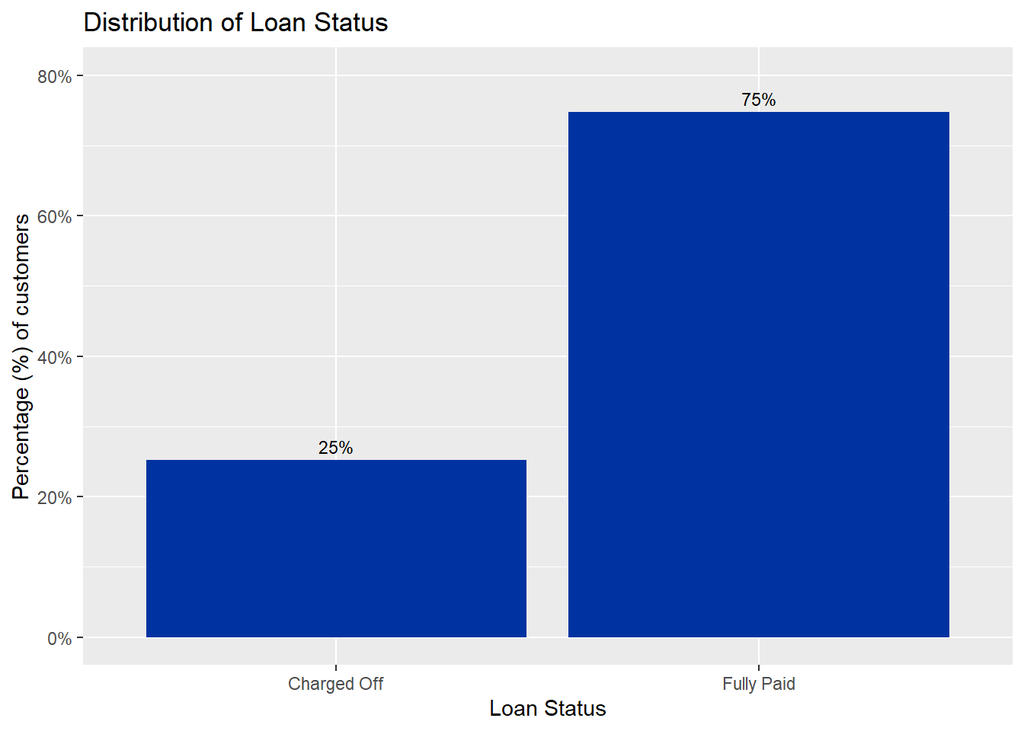

```r
#summarize
ln.status<-data%>%
  select (Loan.Status)%>%
  group_by(Loan.Status)%>%
  summarise(count=n())

ln.status<-ln.status%>%
  mutate(percentage=(count/sum(count))*100)

#Create a bar graph
ln.status%>%
  ggplot(aes(x=Loan.Status,y=percentage))+geom_bar(stat="identity",fill="#0033A1")+labs(x="Loan Status",y="Percentage (%) of customers")+ geom_text(aes(label = paste0(round(percentage), "%")), vjust = -0.5, size = 3, color = "black")+ggtitle("Distribution of Loan Status")+scale_y_continuous(limits = c(0,80), breaks = seq(0,80,20), labels = c("0%", "20%", "40%","60%","80%"))
```

Explore distribution of Customer Income Level

```r
#First, I will need to create levels within income level since it is a continous variable
#Round it off to whole number
inc<-data%>%
  select(Annual.Income)
inc$Annual.Income<-round(inc$Annual.Income)
#Explore summary of the variables to have a clue on how to create new levels
summary(inc$Annual.Income)
```

```
##      Min.   1st Qu.    Median      Mean   3rd Qu.      Max.
##     76627    878959   1198653   1376469   1634494 165557393
```

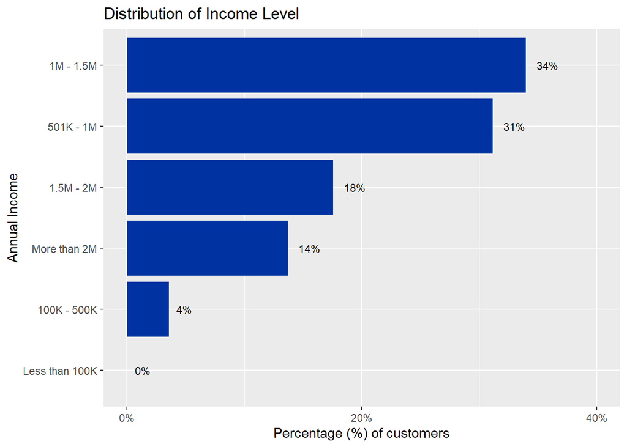

```r
inc <- inc %>%
  mutate(income_classes = case_when(
    `Annual.Income` < 100000 ~ "Less than 100K",
    `Annual.Income` >= 100000 & `Annual.Income` <= 500000 ~ "100K - 500K",
    `Annual.Income` > 500000 & `Annual.Income` <= 1000000 ~ "501K - 1M",
    `Annual.Income` > 1000000 & `Annual.Income` <= 1500000 ~ "1M - 1.5M",
    `Annual.Income` > 1500000 & `Annual.Income` <= 2000000 ~ "1.5M - 2M",
    `Annual.Income` > 2000000 ~ "More than 2M"
  ))

#Summarize
inc.sum<-inc%>%
  select(income_classes)%>%
  group_by(income_classes)%>%
  summarise(count=n())
inc.sum<-inc.sum%>%
  mutate(percentage=(count/sum(count))*100)

#Now create a bar graph to represent this
inc.sum%>%
  ggplot(aes(x=reorder(income_classes,percentage),y=percentage))+geom_bar(stat="identity",fill="#0033A1")+labs(x="Annual Income",y="Percentage (%) of customers")+geom_text(aes(label = paste0(round(percentage), "%")), hjust = -0.5, size = 3, color = "black")+ggtitle("Distribution of Income Level")+coord_flip()+scale_y_continuous(limits = c(0,40), breaks = seq(0,40,20), labels = c("0%", "20%", "40%"))
```

Explore distribution of years in current job

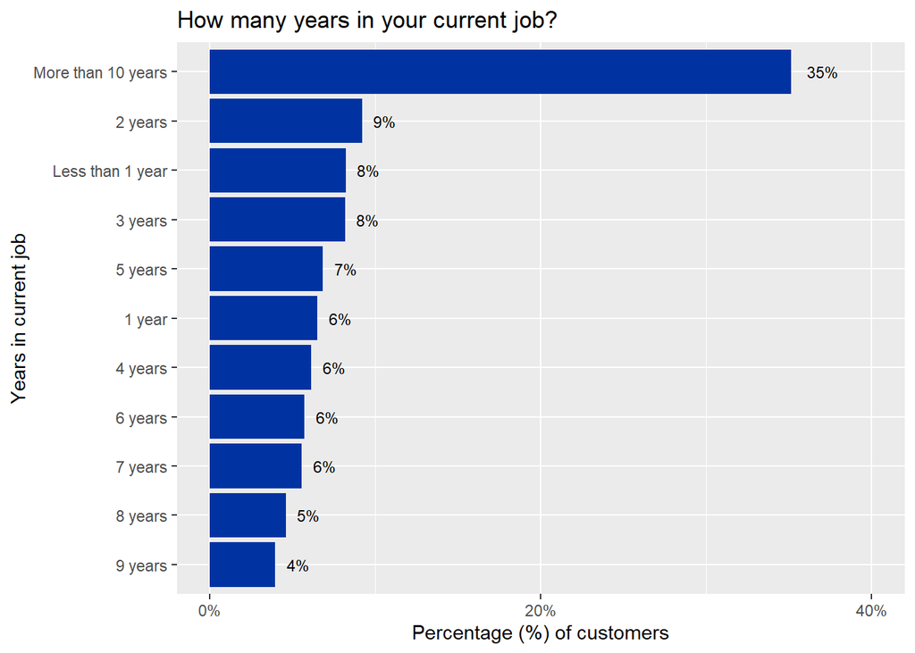

```r
years<-data%>%
  select(Years.in.current.job)
#Summarize
years.sum<-years%>%
  select(Years.in.current.job)%>%
  group_by(Years.in.current.job)%>%
  summarise(count=n())
years.sum<-years.sum%>%
  mutate(percentage=(count/sum(count))*100)

#Now create a bar graph to represent this
years.sum%>%
  ggplot(aes(x=reorder(Years.in.current.job,percentage),y=percentage))+geom_bar(stat="identity",fill="#0033A1")+labs(x="Years in current job",y="Percentage (%) of customers")+geom_text(aes(label = paste0(round(percentage), "%")), hjust = -0.5, size = 3, color = "black")+ggtitle("How many years in your current job?")+coord_flip()+scale_y_continuous(limits = c(0,40), breaks = seq(0,40,20), labels = c("0%", "20%", "40%"))
```

Explore the home ownership of the customers

```r
#Explore the unique instances of home ownership
unique(data$Home.Ownership) #"Home Mortgage" and "HaveMortgage" seem to be repeated. Combine them
```

```
## [1] "Home Mortgage" "Own Home"      "Rent"          "HaveMortgage"
```

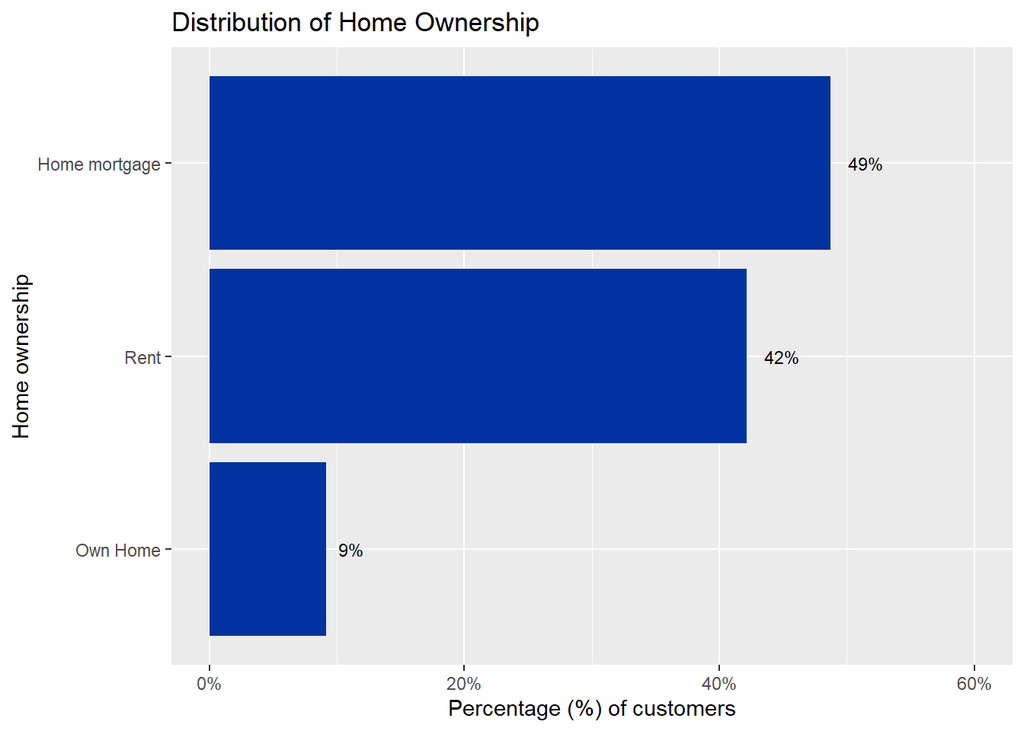

```r
data <- data %>%
  mutate(Home.Ownership = case_when(
    Home.Ownership %in% c("HaveMortgage", "Home Mortgage") ~ "Home mortgage",
    TRUE ~ Home.Ownership
  ))
#summarize
home<-data%>%
  select (Home.Ownership)%>%
  group_by(Home.Ownership)%>%
  summarise(count=n())

home<-home%>%
  mutate(percentage=(count/sum(count))*100)


#Create a bar graph
home %>%
  ggplot(aes(x = reorder(Home.Ownership, percentage), y = percentage)) +
  geom_bar(stat = "identity", fill = "#0033A1") +
  labs(x = "Home ownership", y = "Percentage (%) of customers") +
  geom_text(aes(label = paste0(round(percentage), "%")), hjust = -0.5, size = 3, color = "black") +
  ggtitle("Distribution of Home Ownership") +
  coord_flip() +
  scale_y_continuous(limits = c(0, 60), breaks = seq(0, 60, 20), labels = c("0%", "20%", "40%", "60%"))
```

Explore distribution of Years of Creadit History

```r
#Fisrt check the summary of the years of credit history
summary(data$Years.of.Credit.History)
```

```
##    Min. 1st Qu.  Median    Mean 3rd Qu.    Max.
##    3.60   13.50   17.00   18.25   21.70   70.50
```

```r
#subste the data
years.credit<-data%>%
  select(Years.of.Credit.History)

#Explore summary of the variables to have a clue on how to create new levels
summary(inc$Annual.Income)
```

```
##      Min.   1st Qu.    Median      Mean   3rd Qu.      Max.
##     76627    878959   1198653   1376469   1634494 165557393
```

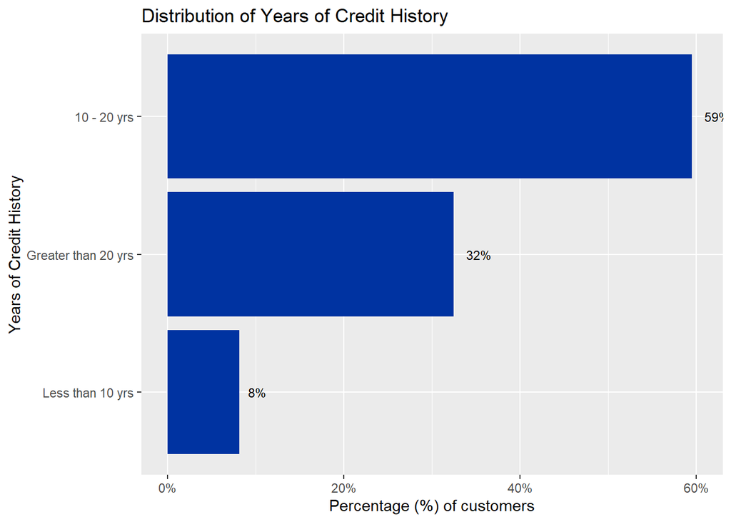

```r
#Create new classifications to help plot
 years.credit<- years.credit %>%
  mutate(years.credit.category = case_when(
    `Years.of.Credit.History` < 10 ~ "Less than 10 yrs",
    `Years.of.Credit.History` >= 10 & `Years.of.Credit.History` <= 20 ~ "10 - 20 yrs",
    `Years.of.Credit.History` > 20  ~ "Greater than 20 yrs",
  ))

#Summarize
years.credit.sum<- years.credit%>%
  select(years.credit.category)%>%
  group_by(years.credit.category)%>%
  summarise(count=n())
years.credit.sum<-years.credit.sum%>%
  mutate(percentage=(count/sum(count))*100)

#Create a bar graph
years.credit.sum %>%
  ggplot(aes(x = reorder(years.credit.category, percentage), y = percentage)) +
  geom_bar(stat = "identity", fill = "#0033A1") +
  labs(x = "Years of Credit History", y = "Percentage (%) of customers") +
  geom_text(aes(label = paste0(round(percentage), "%")), hjust = -0.5, size = 3, color = "black") +
  ggtitle("Distribution of Years of Credit History") +
  coord_flip() +
  scale_y_continuous(limits = c(0, 60), breaks = seq(0, 60, 20), labels = c("0%", "20%", "40%", "60%"))
```

Explore distribution of Credit Score

```r
#Fisrt check the summary of the years of credit history
summary(data$Credit.Score)
```

```
##    Min. 1st Qu.  Median    Mean 3rd Qu.    Max.
##   585.0   713.0   719.0   718.7   737.0   751.0
```

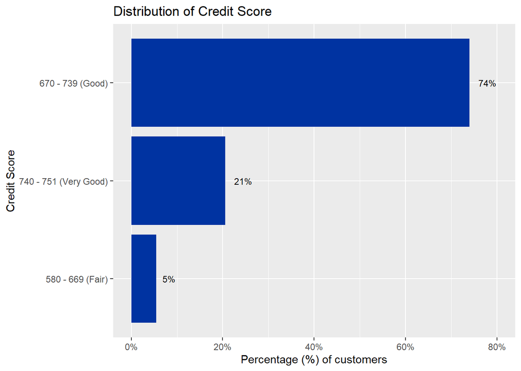

```r
#subste the data
credit.s<-data%>%
  select(Credit.Score)

#Create new classifications to help plot
 credit.s<- credit.s %>%
  mutate(credit.score.category = case_when(
    `Credit.Score` >=580 & `Credit.Score` <= 669 ~ "580 - 669 (Fair)",
    `Credit.Score` >= 670 & `Credit.Score` <= 739 ~ "670 - 739 (Good)",
    `Credit.Score` >= 740 & `Credit.Score` <=751 ~ "740 - 751 (Very Good)"
  ))

#Summarize
 credit.sum<- credit.s%>%
  select(credit.score.category)%>%
  group_by(credit.score.category)%>%
  summarise(count=n())
credit.sum<-credit.sum%>%
  mutate(percentage=(count/sum(count))*100)

#Create a bar graph
credit.sum %>%
  ggplot(aes(x = reorder(credit.score.category, percentage), y = percentage)) +
  geom_bar(stat = "identity", fill = "#0033A1") +
  labs(x = "Credit Score", y = "Percentage (%) of customers") +
  geom_text(aes(label = paste0(round(percentage), "%")), hjust = -0.5, size = 3, color = "black") +
  ggtitle("Distribution of Credit Score") +
  coord_flip() +
  scale_y_continuous(limits = c(0, 80), breaks = seq(0, 80, 20), labels = c("0%", "20%", "40%", "60%","80%"))
```

Explore distribution of loan term

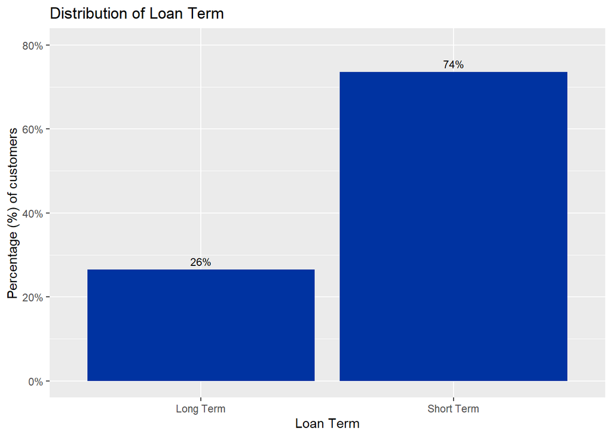

```r
#summarize
ln.term<-data%>%
  select (Term)%>%
  group_by(Term)%>%
  summarise(count=n())

ln.term<-ln.term%>%
  mutate(percentage=(count/sum(count))*100)

#Create a bar graph
ln.term%>%
  ggplot(aes(x=Term,y=percentage))+geom_bar(stat="identity",fill="#0033A1")+labs(x="Loan Term",y="Percentage (%) of customers")+ geom_text(aes(label = paste0(round(percentage), "%")), vjust = -0.5, size = 3, color = "black")+ggtitle("Distribution of Loan Term")+scale_y_continuous(limits = c(0,80), breaks = seq(0,80,20), labels = c("0%", "20%", "40%","60%","80%"))
```

Explore distribution of Loan purpose

```r
#Check the unique options under loan purpose
unique(data$Purpose)
```

```
##  [1] "Home Improvements"    "Debt Consolidation"   "Buy House"
##  [4] "other"                "Business Loan"        "Buy a Car"
##  [7] "major_purchase"       "Take a Trip"          "Other"
## [10] "small_business"       "Medical Bills"        "wedding"
## [13] "vacation"             "Educational Expenses" "moving"
## [16] "renewable_energy"
```

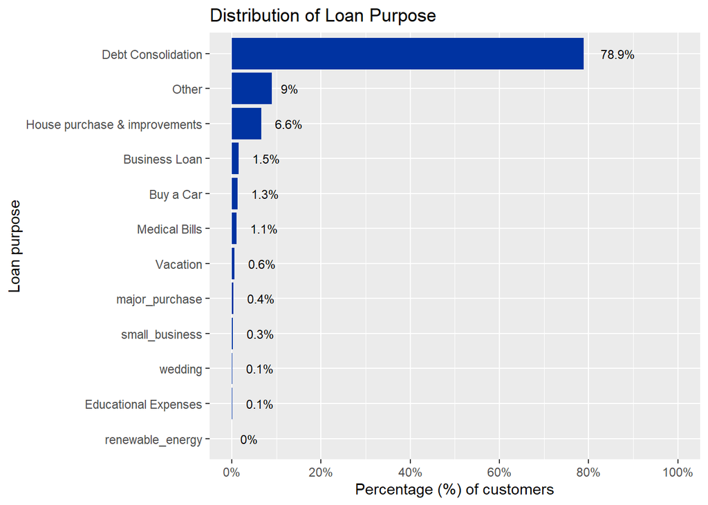

```r
#combine some choices with typos or overlap
data <- data %>%
  mutate(Purpose = case_when(
    Purpose %in% c("Buy House", "Home Improvements","moving") ~ "House purchase & improvements",
    Purpose %in% c("other", "Other") ~ "Other",
    Purpose %in% c("vacation", "Take a Trip") ~ "Vacation",
    TRUE ~ Purpose
  ))
#Summarize
 ln.purpose<-data%>%
  select(Purpose)%>%
  group_by(Purpose)%>%
  summarise(count=n())
ln.purpose<-ln.purpose%>%
  mutate(percentage=(count/sum(count))*100)

#Create a bar graph
ln.purpose %>%
  ggplot(aes(x = reorder(Purpose, percentage), y = percentage)) +
  geom_bar(stat = "identity", fill = "#0033A1") +
  labs(x = "Loan purpose", y = "Percentage (%) of customers") +
  geom_text(aes(label = paste0(round(percentage,1), "%")), hjust = -0.5, size = 3, color = "black") +
  ggtitle("Distribution of Loan Purpose") +
  coord_flip() +
  scale_y_continuous(limits = c(0, 100), breaks = seq(0, 100, 20), labels = c("0%", "20%", "40%", "60%","80%","100%"))
```

Explore distribution of Loan amount

```r
#Fisrt explore the summary
summary(data$Current.Loan.Amount)
```

```
##    Min. 1st Qu.  Median    Mean 3rd Qu.    Max.
##   10802  180268  232518  297992  396924  789250
```

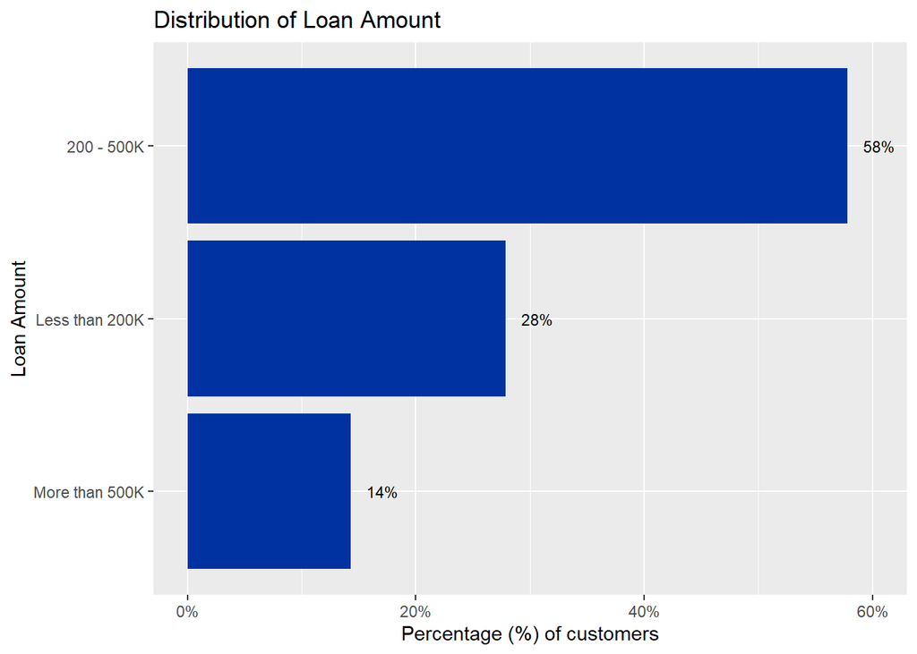

```r
#subset data
ln.amt<-data%>%
  select(Current.Loan.Amount)
#create loan amount categories
ln.amt<- ln.amt %>%
  mutate(ln.amt.category = case_when(
    `Current.Loan.Amount` < 200000  ~ "Less than 200K",
    `Current.Loan.Amount` >= 200000 & `Current.Loan.Amount` <= 500000 ~ "200 - 500K",
    `Current.Loan.Amount` >= 500001 ~ "More than 500K"
  ))

#Summarize
 ln.amt.s<-ln.amt%>%
  select(ln.amt.category)%>%
  group_by(ln.amt.category)%>%
  summarise(count=n())
ln.amt.s<-ln.amt.s%>%
  mutate(percentage=(count/sum(count))*100)

#Create a bar graph
ln.amt.s %>%
  ggplot(aes(x = reorder(ln.amt.category, percentage), y = percentage)) +
  geom_bar(stat = "identity", fill = "#0033A1") +
  labs(x = "Loan Amount", y = "Percentage (%) of customers") +
  geom_text(aes(label = paste0(round(percentage), "%")), hjust = -0.5, size = 3, color = "black") +
  ggtitle("Distribution of Loan Amount") +
  coord_flip() +
  scale_y_continuous(limits = c(0, 60), breaks = seq(0, 60, 20), labels = c("0%", "20%", "40%", "60%"))
```

Now, explore crosstabulations with the target variable as well as among the independent variables

1. How does the loan status of customers vary with the home ownership status?

```r
#subset the data
ln.v.hm<-data%>%
  select(Loan.Status,Home.Ownership)%>%
  group_by(Loan.Status,Home.Ownership)%>%
  summarise(count=n())
ln.v.hm<-ln.v.hm%>%
  mutate(percentage=count/sum(count)*100)
#pallet of colors
```

[output not shown]

2.) How does the loan status vary based on the term of the loan

```r
#subset the data
ln.v.tm<-data%>%
  select(Loan.Status,Term)%>%
  group_by(Loan.Status,Term)%>%
  summarise(count=n())
```

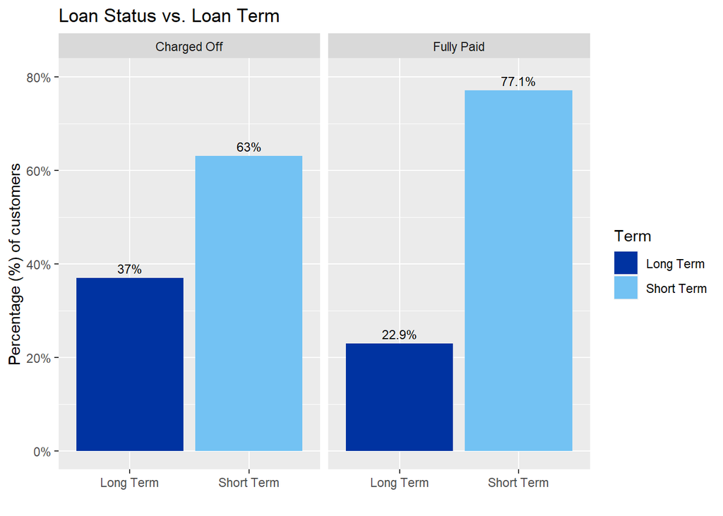

```r
ln.v.tm<-ln.v.tm%>%
  mutate(percentage=count/sum(count)*100)


#Create a bar graph
ln.v.tm %>%
  ggplot(aes(x = Term, y = percentage, fill = Term)) +
  geom_bar(stat = "identity") +
  labs(x="",y = "Percentage (%) of customers") +
  geom_text(aes(label = paste0(round(percentage,1), "%")), vjust = -0.5, size = 3, color = "black") +
  ggtitle("Loan Status vs. Loan Term") +
  scale_y_continuous(limits = c(0, 80), breaks = seq(0, 80, 20), labels = c("0%", "20%", "40%", "60%", "80%")) +
  facet_wrap(~Loan.Status) +
  pal
```

This seems consistent with the overall distribution (more short term than long term loans). However, worth to note that there are more (37%) of long term loans in the charged off category than in the Fully paid category (23%). This could imply that long term loans are more likely to end up in default.

3.) How does loan status vary with annual income

```r
#combine loan status with income category classified earliar
ln.v.inc<-data.frame(Loan_status=data$Loan.Status,income_category=inc$income_classes)

inc_sumary<-ln.v.inc%>%
group_by(Loan_status,income_category)%>%
  summarise(count=n())
```

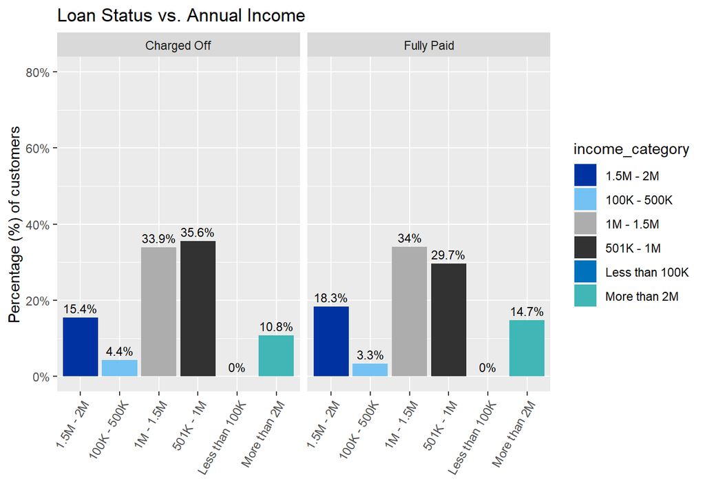

```r
inc_sumary<-inc_sumary%>%
  mutate(percentage=count/sum(count)*100)


#Create a bar graph
inc_sumary %>%
  ggplot(aes(x = income_category, y = percentage, fill = income_category)) +
  geom_bar(stat = "identity") +
  labs(x="",y = "Percentage (%) of customers") +
  geom_text(aes(label = paste0(round(percentage,1), "%")), vjust = -0.5, size = 3, color = "black") +
  ggtitle("Loan Status vs. Annual Income") +
  scale_y_continuous(limits = c(0, 80), breaks = seq(0, 80, 20), labels = c("0%", "20%", "40%", "60%", "80%")) +
  facet_wrap(~Loan_status) +
  pal +theme(axis.text.x = element_text(angle = 60, hjust = 1))
```

This is consisitent with the overall distribution of Annual income, however it is inferable that it is more riskier to lend to customers with an annual income of 500,000 to 1,000,000 than any other income category.

4.) How does Loan status vary with the current Loan Amount?

```r
#Create a dataframe to hold loan amount category and loan status
amt.v.status<-data.frame(loan.status=data$Loan.Status,loan.amount.category=ln.amt$ln.amt.category)

amt_sumary<-amt.v.status%>%
group_by(loan.status,loan.amount.category)%>%
  summarise(count=n())
```

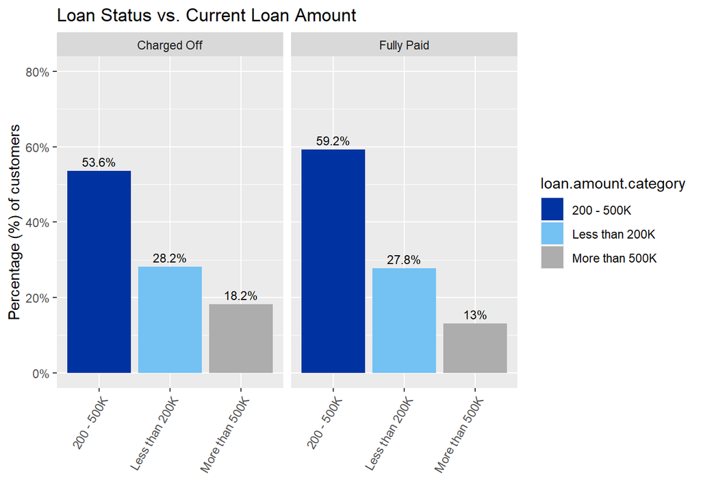

```r
amt_sumary<-amt_sumary%>%
  mutate(percentage=count/sum(count)*100)


#Create a bar graph
amt_sumary %>%
  ggplot(aes(x = loan.amount.category, y = percentage, fill = loan.amount.category)) +
  geom_bar(stat = "identity") +
  labs(x="",y = "Percentage (%) of customers") +
  geom_text(aes(label = paste0(round(percentage,1), "%")), vjust = -0.5, size = 3, color = "black") +
  ggtitle("Loan Status vs. Current Loan Amount") +
  scale_y_continuous(limits = c(0, 80), breaks = seq(0, 80, 20), labels = c("0%", "20%", "40%", "60%", "80%")) +
  facet_wrap(~loan.status) +
  pal +theme(axis.text.x = element_text(angle = 60, hjust = 1))
```

5)How does Loan status vary with the creditr score?

```r
#create data frame
ln.v.cscore<-data.frame(loan.status=data$Loan.Status,credit.score.cat=credit.s$credit.score.category)

cs_sumary<-ln.v.cscore%>%
group_by(loan.status,credit.score.cat)%>%
  summarise(count=n())
```

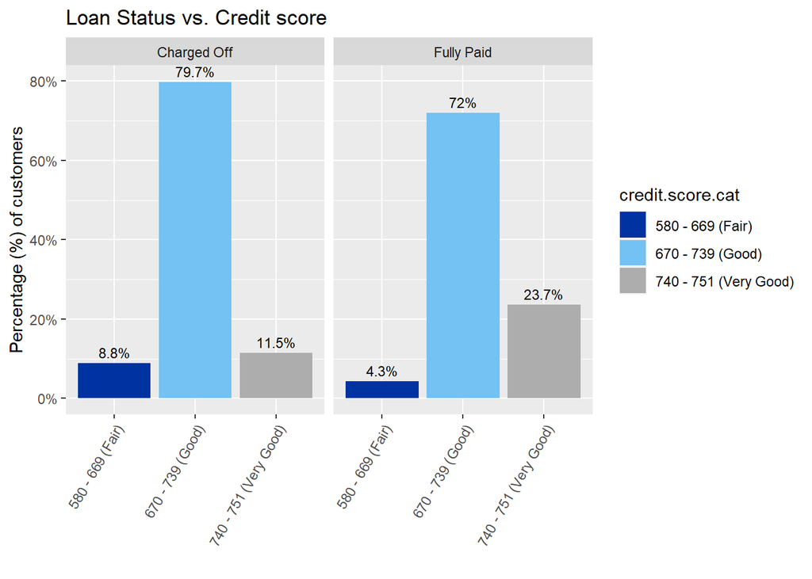

```r
cs_sumary<-cs_sumary%>%
  mutate(percentage=count/sum(count)*100)


#Create a bar graph
cs_sumary %>%
  ggplot(aes(x = credit.score.cat, y = percentage, fill = credit.score.cat)) +
  geom_bar(stat = "identity") +
  labs(x="",y = "Percentage (%) of customers") +
  geom_text(aes(label = paste0(round(percentage,1), "%")), vjust = -0.5, size = 3, color = "black") +
  ggtitle("Loan Status vs. Credit score") +
  scale_y_continuous(limits = c(0, 80), breaks = seq(0, 80, 20), labels = c("0%", "20%", "40%", "60%", "80%")) +
  facet_wrap(~loan.status) +
  pal +theme(axis.text.x = element_text(angle = 60, hjust = 1))
```

This is consistent with the overall distribution of credit score categories. However, a point to note, unlike the Fair and Good categories where there are higher percenatge of defaulters than those who fully paid their loans, the Very Good category has a higher (12.2% more) percentage in the fully paid category than the charged off category

6)How does the loan status vary with the years of credit history?

```r
#Explore the years of credit history to categorize
summary(data$Years.of.Credit.History)
```

```
##    Min. 1st Qu.  Median    Mean 3rd Qu.    Max.
##    3.60   13.50   17.00   18.25   21.70   70.50
```

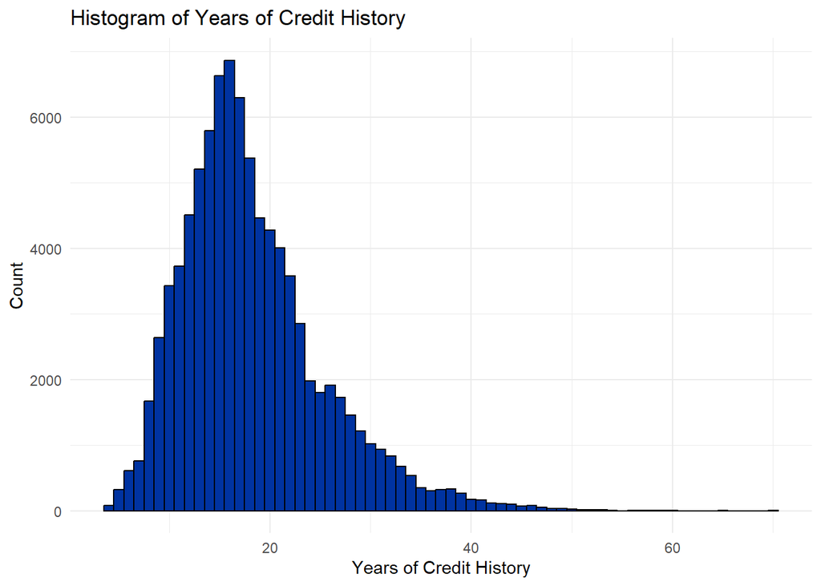

```r
ln.v.crhist<-data.frame(loan.status=data$Loan.Status,cr.hist=data$Years.of.Credit.History)
#Create categories
ln.v.crhist<- ln.v.crhist %>%
  mutate(hist.category = case_when(
    `cr.hist` < 5  ~ "Less than 5yrs",
    `cr.hist` >= 5 & `cr.hist` <= 10 ~ "5 - 10yrs",
    `cr.hist` >= 10.1 & `cr.hist` <= 20 ~ "11 - 20yrs",
    `cr.hist` >= 20.1 ~ "More than 20yrs"
  ))

#Create a bar graph to show count
ggplot(data, aes(x =Years.of.Credit.History )) +
  geom_histogram(binwidth = 1, fill = "#0033A1", color = "black") +
  labs(title = "Histogram of Years of Credit History",
       x = "Years of Credit History",
       y = "Count") +
  theme_minimal()
```

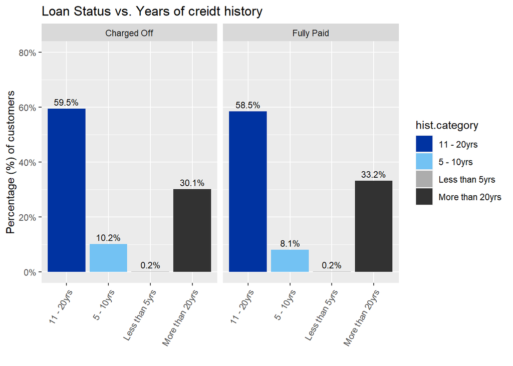

```r
#Shows a pretty noraml distribution, with majority being between 10 and 20 years of credit history

#subset the data to create a crosstab of years of credit history and loan status
ln.v.crhist<- ln.v.crhist %>%
  select(loan.status,hist.category)
#summarise
hist_sumary<-ln.v.crhist%>%
group_by(loan.status,hist.category)%>%
  summarise(count=n())
hist_sumary<-hist_sumary%>%
  mutate(percentage=count/sum(count)*100)


#Create a bar graph
hist_sumary %>%
  ggplot(aes(x = hist.category, y = percentage, fill = hist.category)) +
  geom_bar(stat = "identity") +
  labs(x="",y = "Percentage (%) of customers") +
  geom_text(aes(label = paste0(round(percentage,1), "%")), vjust = -0.5, size = 3, color = "black") +
  ggtitle("Loan Status vs. Years of creidt history") +
  scale_y_continuous(limits = c(0, 80), breaks = seq(0, 80, 20), labels = c("0%", "20%", "40%", "60%", "80%")) +
  facet_wrap(~loan.status) +
  pal +theme(axis.text.x = element_text(angle = 60, hjust = 1))
```

The bar graph is consistent with the overal distribution of years of credit history

7)How does Loan Status vary with months since last deliquent?

```r
#Explore the years of credit history to categorize
summary(data$Months.since.last.delinquent)
```

```
##    Min. 1st Qu.  Median    Mean 3rd Qu.    Max.
##    0.00   24.00   34.20   35.13   44.40  176.00
```

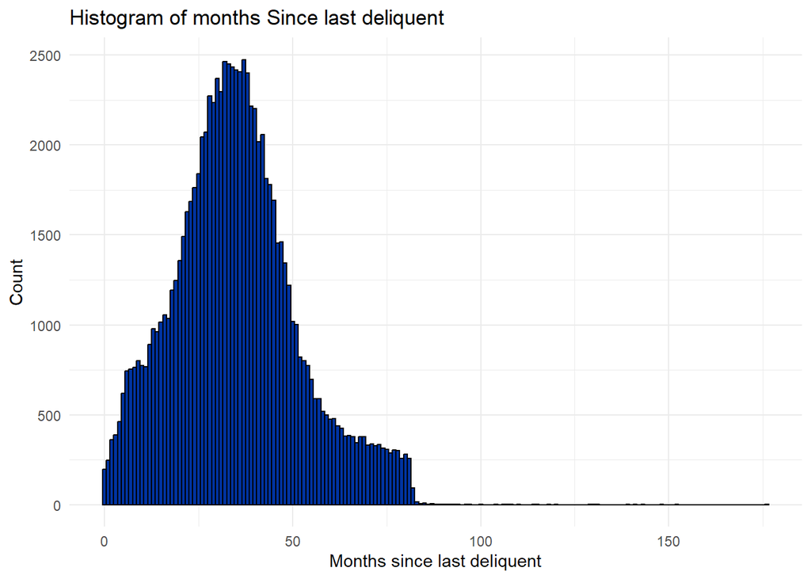

```r
ln.v.months<-data.frame(loan.status=data$Loan.Status,months.since.deliquent=data$Months.since.last.delinquent)
#Create categories
ln.v.months<- ln.v.months %>%
  mutate(months.category = case_when(
    `months.since.deliquent` < 12  ~ "Less than 12 months",
    `months.since.deliquent` >= 12 & `months.since.deliquent` <= 24 ~ "12-24 months",
    `months.since.deliquent` >= 24.01 & `months.since.deliquent` <= 48 ~ "24-48 months",
    `months.since.deliquent` >= 48.01 ~ "More than 48 months"
  ))

#Create a bar graph to show count
ggplot(data, aes(x =Months.since.last.delinquent)) +
  geom_histogram(binwidth = 1, fill = "#0033A1", color = "black") +
  labs(title = "Histogram of months Since last deliquent",
       x = "Months since last deliquent",
       y = "Count") +
  theme_minimal()
```

```r
#Shows a pretty noraml distribution, with majority being between 12 and 50 months since last deliquent

#subset the data to create a crosstab of months since deliquent and loan status
ln.v.months<- ln.v.months %>%
  select(loan.status,months.category)
#summarise
month_sumary<-ln.v.months%>%
group_by(loan.status,months.category)%>%
  summarise(count=n())
```

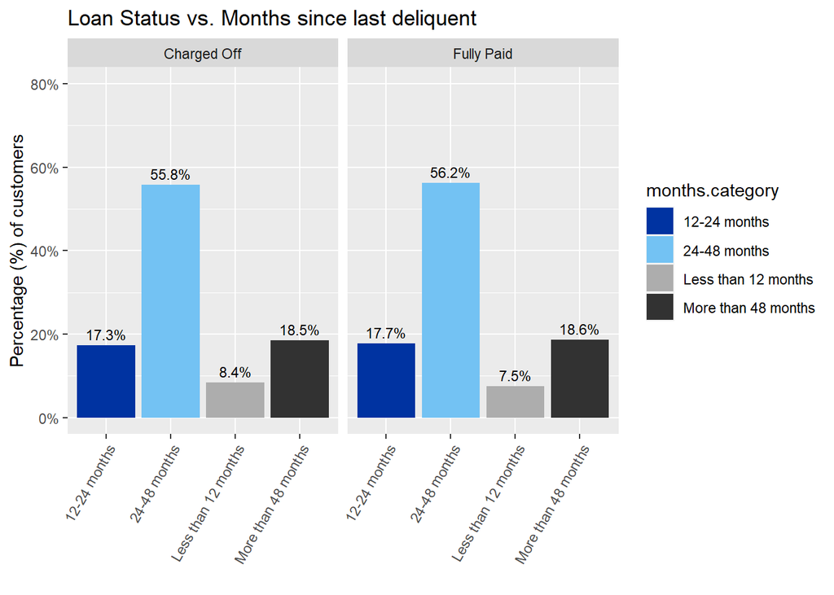

```r
month_sumary<-month_sumary%>%
  mutate(percentage=count/sum(count)*100)


#Create a bar graph
month_sumary %>%
  ggplot(aes(x = months.category, y = percentage, fill = months.category)) +
  geom_bar(stat = "identity") +
  labs(x="",y = "Percentage (%) of customers") +
  geom_text(aes(label = paste0(round(percentage,1), "%")), vjust = -0.5, size = 3, color = "black") +
  ggtitle("Loan Status vs. Months since last deliquent") +
  scale_y_continuous(limits = c(0, 80), breaks = seq(0, 80, 20), labels = c("0%", "20%", "40%", "60%", "80%")) +
  facet_wrap(~loan.status) +
  pal +theme(axis.text.x = element_text(angle = 60, hjust = 1))
```

Consistent with the overall distribution of months since last deliquent, majority in both loans charged off and those fully paid have 24-48 months since they were last deliquent

8. How does loan status vary with current credit balance

```r
#Explore the years of credit history to categorize
summary(data$Current.Credit.Balance)
```

```
##     Min.  1st Qu.   Median     Mean  3rd Qu.     Max.
##        0   112936   209722   294035   367517 32878968
```

```r
ln.v.crbalance<-data.frame(loan.status=data$Loan.Status,credit.balance=data$Current.Credit.Balance)
#Create categories
ln.v.crbalance<- ln.v.crbalance %>%
  mutate(credit.category = case_when(
    `credit.balance` < 115000  ~ "Less than 115K",
    `credit.balance` >= 115000 & `credit.balance` <= 210000 ~ "115K-210K",
    `credit.balance` >= 210001 & `credit.balance` <= 400000 ~ "210K-400K",
    `credit.balance` >= 400001 ~ "More than 400K"
  ))

#subset the data to create a crosstab of credit balance and loan status
ln.v.bal<- ln.v.crbalance %>%
  select(loan.status,credit.category)
#summarise
bal_sumary<-ln.v.bal%>%
group_by(loan.status,credit.category)%>%
  summarise(count=n())
```

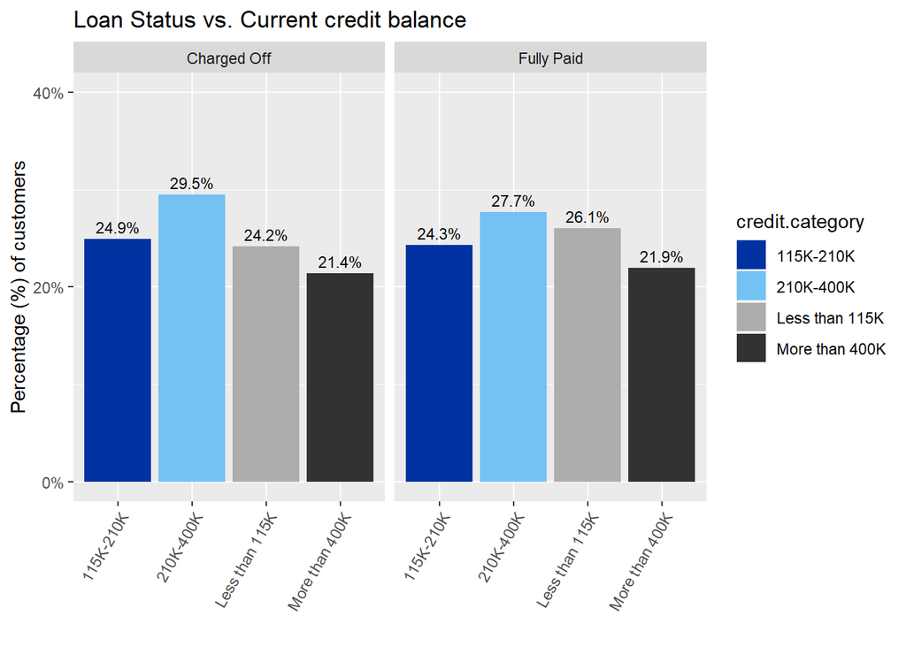

```r
bal_sumary<-bal_sumary%>%
  mutate(percentage=count/sum(count)*100)


#Create a bar graph
bal_sumary %>%
  ggplot(aes(x = credit.category, y = percentage, fill =credit.category)) +
  geom_bar(stat = "identity") +
  labs(x="",y = "Percentage (%) of customers") +
  geom_text(aes(label = paste0(round(percentage,1), "%")), vjust = -0.5, size = 3, color = "black") +
  ggtitle("Loan Status vs. Current credit balance") +
  scale_y_continuous(limits = c(0, 40), breaks = seq(0, 40, 20), labels = c("0%", "20%", "40%")) +
  facet_wrap(~loan.status) +
  pal +theme(axis.text.x = element_text(angle = 60, hjust = 1))
```

Not so much, evenly distributed across credit balance categories

#Explore the Association or Correlation between the independent variables versus the target variable

1. Explore the relationship between loan status versus the current loan amount

```r
#First, convert the target variable to a dummy variable
data <- data %>%
  mutate(Loan.Status = ifelse(Loan.Status == 'Fully Paid', 1, 0))
#Conduct a t-test to check if the mean current loan amount is different between the two groups
t_test_result <- t.test(Current.Loan.Amount ~ Loan.Status, data = data)
#silence scientific
options(scipen = 999)
# Print the t-test result
print(t_test_result)
```

```
##
##  Welch Two Sample t-test
##
## data:  Current.Loan.Amount by Loan.Status
## t = 25.789, df = 36246, p-value < 0.00000000000000022
## alternative hypothesis: true difference in means between group 0 and group 1 is not equal to 0
## 95 percent confidence interval:
##  33338.58 38823.13
## sample estimates:
## mean in group 0 mean in group 1
##        324975.2        288894.4
```

```r
#Check the nature of the relationship using logistic regression
# Fit logistic regression model
logistic_model <- glm(Loan.Status ~ Current.Loan.Amount, data = data, family = binomial)

# Summarize the model
summary(logistic_model)
```

```
##
## Call:
## glm(formula = Loan.Status ~ Current.Loan.Amount, family = binomial,
##     data = data)
##
## Coefficients:
##                          Estimate    Std. Error z value            Pr(>|z|)
## (Intercept)          1.4348480165  0.0154320754   92.98 <0.0000000000000002 ***
## Current.Loan.Amount -0.0000011347  0.0000000425  -26.70 <0.0000000000000002 ***
## ---
## Signif. codes:  0 '***' 0.001 '**' 0.01 '*' 0.05 '.' 0.1 ' ' 1
##
## (Dispersion parameter for binomial family taken to be 1)
##
##     Null deviance: 101400  on 89784  degrees of freedom
## Residual deviance: 100699  on 89783  degrees of freedom
## AIC: 100703
##
## Number of Fisher Scoring iterations: 4
```

There is a statistically significant difference between the average current loan amount of the Fully Paid category (288894.4) and the average current loan amount of the Charged off category (324975.2), p=0.

The logistic regression model shows that there is a statistically significant relationship between the loan status and teh current loan amount (p=0).The negative coeffiecient in the current loan amount indicate that as the current loan amount increases the logg odds of the loan being fully paid decrease.

Next, explore the nature of relationship between loan status and loan term

```r
## Fit logistic regression model
logistic_model <- glm(Loan.Status ~ Term, data = data, family = binomial)

# Summarize the model
summary(logistic_model)
```

```
##
## Call:
## glm(formula = Loan.Status ~ Term, family = binomial, data = data)
##
## Coefficients:
##                Estimate Std. Error z value            Pr(>|z|)
## (Intercept)     0.60993    0.01358   44.91 <0.0000000000000002 ***
## TermShort Term  0.67812    0.01655   40.98 <0.0000000000000002 ***
## ---
## Signif. codes:  0 '***' 0.001 '**' 0.01 '*' 0.05 '.' 0.1 ' ' 1
##
## (Dispersion parameter for binomial family taken to be 1)
##
##     Null deviance: 101400  on 89784  degrees of freedom
## Residual deviance:  99762  on 89783  degrees of freedom
## AIC: 99766
##
## Number of Fisher Scoring iterations: 4
```

There is a statistically significant relationship between the loan status and the term of the loan. If the loan is long term the log odds of the loan being fully paid increase by 0.60993, while when the loan is short term the log odds of the loan being fully paid increase by 0.67812. Since log odds for short term loans are higher, giving out more short term loans would improve the chances of a loan being repaid.

Next, explore the nature of relationship between loan status and credit score

```r
## Fit logistic regression model
logistic_model <- glm(Loan.Status ~ Credit.Score, data = data, family = binomial)

# Summarize the model
summary(logistic_model)
```

```
##
## Call:
## glm(formula = Loan.Status ~ Credit.Score, family = binomial,
##     data = data)
##
## Coefficients:
##                Estimate Std. Error z value            Pr(>|z|)
## (Intercept)  -7.7360076  0.2085954  -37.09 <0.0000000000000002 ***
## Credit.Score  0.0123065  0.0002913   42.24 <0.0000000000000002 ***
## ---
## Signif. codes:  0 '***' 0.001 '**' 0.01 '*' 0.05 '.' 0.1 ' ' 1
##
## (Dispersion parameter for binomial family taken to be 1)
##
##     Null deviance: 101400  on 89784  degrees of freedom
## Residual deviance:  99636  on 89783  degrees of freedom
## AIC: 99640
##
## Number of Fisher Scoring iterations: 4
```

Next, Explore the nature of relationship between loan status and annual income

```r
## Fit logistic regression model
logistic_model <- glm(Loan.Status ~ Annual.Income, data = data, family = binomial)
# Summarize the model
summary(logistic_model)
```

```
##
## Call:
## glm(formula = Loan.Status ~ Annual.Income, family = binomial,
##     data = data)
##
## Coefficients:
##                    Estimate    Std. Error z value            Pr(>|z|)
## (Intercept)   0.83439531902 0.01627993564   51.25 <0.0000000000000002 ***
## Annual.Income 0.00000018849 0.00000001095   17.22 <0.0000000000000002 ***
## ---
## Signif. codes:  0 '***' 0.001 '**' 0.01 '*' 0.05 '.' 0.1 ' ' 1
##
## (Dispersion parameter for binomial family taken to be 1)
##
##     Null deviance: 101400  on 89784  degrees of freedom
## Residual deviance: 101073  on 89783  degrees of freedom
## AIC: 101077
##
## Number of Fisher Scoring iterations: 5
```

There is a significant relationship between annual income and loan status, with the positive coefficient indicating that as annual income increases, the log odds of a loan being fully repaid increase, albeit very small increase in odds. However, taing exponents of the log odds, shows that an increas ein annual income has no effect on the outcome (loan being fully paid)

Next, explore nature of relationship between loan status and monthly debt

```r
## Fit logistic regression model
logistic_model <- glm(Loan.Status ~ Monthly.Debt, data = data, family = binomial)

# Summarize the model
summary(logistic_model)
```

```
##
## Call:
## glm(formula = Loan.Status ~ Monthly.Debt, family = binomial,
##     data = data)
##
## Coefficients:
##                   Estimate    Std. Error z value             Pr(>|z|)
## (Intercept)   1.1290790872  0.0139026352  81.213 < 0.0000000000000002 ***
## Monthly.Debt -0.0000022665  0.0000006242  -3.631             0.000282 ***
## ---
## Signif. codes:  0 '***' 0.001 '**' 0.01 '*' 0.05 '.' 0.1 ' ' 1
##
## (Dispersion parameter for binomial family taken to be 1)
##
##     Null deviance: 101400  on 89784  degrees of freedom
## Residual deviance: 101387  on 89783  degrees of freedom
## AIC: 101391
##
## Number of Fisher Scoring iterations: 4
```

There is a significnat relationship between loan status and monthly debt. The negative coefficient indicates that as monthly debt increases the log odds of a loan being fully paid decrease, albeit by small odd.

Next, expore relationship between loan status and Years of credit history

```r
## Fit logistic regression model
logistic_model <- glm(Loan.Status ~ Years.of.Credit.History, data = data, family = binomial)

# Summarize the model
summary(logistic_model)
```

```
##
## Call:
## glm(formula = Loan.Status ~ Years.of.Credit.History, family = binomial,
##     data = data)
##
## Coefficients:
##                         Estimate Std. Error z value            Pr(>|z|)
## (Intercept)             0.908901   0.021497  42.280 <0.0000000000000002 ***
## Years.of.Credit.History 0.009836   0.001115   8.822 <0.0000000000000002 ***
## ---
## Signif. codes:  0 '***' 0.001 '**' 0.01 '*' 0.05 '.' 0.1 ' ' 1
##
## (Dispersion parameter for binomial family taken to be 1)
##
##     Null deviance: 101400  on 89784  degrees of freedom
## Residual deviance: 101321  on 89783  degrees of freedom
## AIC: 101325
##
## Number of Fisher Scoring iterations: 4
```

The relationship is significant. When a customer has zero years of credit history there are 0.908901 logg odds of the loan being fully paid. As the years of credit history increase, the log odds of a loan being repaid increase by 0.009836. Very significant.

Next, explore nature of relationship between loan status and months since last deliquent

```r
## Fit logistic regression model
logistic_model <- glm(Loan.Status ~ Months.since.last.delinquent, data = data, family = binomial)

# Summarize the model
summary(logistic_model)
```

```
##
## Call:
## glm(formula = Loan.Status ~ Months.since.last.delinquent, family = binomial,
##     data = data)
##
## Coefficients:
##                               Estimate Std. Error z value            Pr(>|z|)
## (Intercept)                  1.0540710  0.0178794  58.955 <0.0000000000000002
## Months.since.last.delinquent 0.0009447  0.0004613   2.048              0.0406
##
## (Intercept)                  ***
## Months.since.last.delinquent *
## ---
## Signif. codes:  0 '***' 0.001 '**' 0.01 '*' 0.05 '.' 0.1 ' ' 1
##
## (Dispersion parameter for binomial family taken to be 1)
##
##     Null deviance: 101400  on 89784  degrees of freedom
## Residual deviance: 101396  on 89783  degrees of freedom
## AIC: 101400
##
## Number of Fisher Scoring iterations: 4
```

The relationship is significant. When the customer has never been deliquent, the log odds of the loan being fully repaid are 1.054. As the moths since last deliquent increase the likelihood of a loan being fully paid increase, however this is not very significant (as indicated by the single asteric)-as you would expect.

Next, explore the relationship between loan status and number of open accounts

```r
## Fit logistic regression model
logistic_model <- glm(Loan.Status ~ Number.of.Open.Accounts, data = data, family = binomial)

# Summarize the model
summary(logistic_model)
```

```
##
## Call:
## glm(formula = Loan.Status ~ Number.of.Open.Accounts, family = binomial,
##     data = data)
##
## Coefficients:
##                          Estimate Std. Error z value             Pr(>|z|)
## (Intercept)              1.155841   0.018722  61.736 < 0.0000000000000002 ***
## Number.of.Open.Accounts -0.006150   0.001524  -4.035            0.0000547 ***
## ---
## Signif. codes:  0 '***' 0.001 '**' 0.01 '*' 0.05 '.' 0.1 ' ' 1
##
## (Dispersion parameter for binomial family taken to be 1)
##
##     Null deviance: 101400  on 89784  degrees of freedom
## Residual deviance: 101384  on 89783  degrees of freedom
## AIC: 101388
##
## Number of Fisher Scoring iterations: 4
```

The relationship is significant. When a customer has zero open accounts, the log odds of a loan being fully repaid increase by 1.155841. The negative coeffciient on number of open accounts indicates that as number of open accounts increase, the likelihood of a loan being fully repaid decrease by -0.006150

Next, explore the nature of relationship between loan status and number of credit problems

```r
## Fit logistic regression model
logistic_model <- glm(Loan.Status ~ Number.of.Credit.Problems, data = data, family = binomial)

# Summarize the model
summary(logistic_model)
```

```
##
## Call:
## glm(formula = Loan.Status ~ Number.of.Credit.Problems, family = binomial,
##     data = data)
##
## Coefficients:
##                            Estimate Std. Error z value            Pr(>|z|)
## (Intercept)                1.092403   0.008134 134.306 <0.0000000000000002 ***
## Number.of.Credit.Problems -0.031231   0.015805  -1.976              0.0481 *
## ---
## Signif. codes:  0 '***' 0.001 '**' 0.01 '*' 0.05 '.' 0.1 ' ' 1
##
## (Dispersion parameter for binomial family taken to be 1)
##
##     Null deviance: 101400  on 89784  degrees of freedom
## Residual deviance: 101396  on 89783  degrees of freedom
## AIC: 101400
##
## Number of Fisher Scoring iterations: 4
```

Relationship is significant. When a customer has zero credit problems, the log odds of the loan being fully repaid increase by 1.092403. The negative coeficient indicate that as the number of credit problems increase the log odds of repaying the loan fully decrease-although not very significant

Next, explore the nature of relationship between loan status and current credit balance

```r
## Fit logistic regression model
logistic_model <- glm(Loan.Status ~ Current.Credit.Balance, data = data, family = binomial)

# Summarize the model
summary(logistic_model)
```

```
##
## Call:
## glm(formula = Loan.Status ~ Current.Credit.Balance, family = binomial,
##     data = data)
##
## Coefficients:
##                             Estimate    Std. Error z value             Pr(>|z|)
## (Intercept)            1.06842401435 0.01006578317 106.144 < 0.0000000000000002
## Current.Credit.Balance 0.00000006432 0.00000002244   2.866              0.00415
##
## (Intercept)            ***
## Current.Credit.Balance **
## ---
## Signif. codes:  0 '***' 0.001 '**' 0.01 '*' 0.05 '.' 0.1 ' ' 1
##
## (Dispersion parameter for binomial family taken to be 1)
##
##     Null deviance: 101400  on 89784  degrees of freedom
## Residual deviance: 101391  on 89783  degrees of freedom
## AIC: 101395
##
## Number of Fisher Scoring iterations: 4
```

Relationship is significant. As credit balance increases the log odds of a loan being fully repaid increase, by a small margin though-moderately significant.

Next, check relationship between loan status and maximum open credit

```r
## Fit logistic regression model
logistic_model <- glm(Loan.Status ~ Maximum.Open.Credit, data = data, family = binomial)

# Summarize the model
summary(logistic_model)
```

```
##
## Call:
## glm(formula = Loan.Status ~ Maximum.Open.Credit, family = binomial,
##     data = data)
##
## Coefficients:
##                          Estimate    Std. Error z value            Pr(>|z|)
## (Intercept)         0.94981928759 0.01441420381   65.89 <0.0000000000000002 ***
## Maximum.Open.Credit 0.00000026726 0.00000002405   11.11 <0.0000000000000002 ***
## ---
## Signif. codes:  0 '***' 0.001 '**' 0.01 '*' 0.05 '.' 0.1 ' ' 1
##
## (Dispersion parameter for binomial family taken to be 1)
##
##     Null deviance: 101400  on 89784  degrees of freedom
## Residual deviance: 101274  on 89783  degrees of freedom
## AIC: 101278
##
## Number of Fisher Scoring iterations: 4
```

Relationship is very significant. As the maximum open credit increases, the log odds of a loan being fully repaid increase-very significant.

Next explore relationship between loan status and bankrupticies

```r
## Fit logistic regression model
logistic_model <- glm(Loan.Status ~ Bankruptcies, data = data, family = binomial)

# Summarize the model
summary(logistic_model)
```

```
##
## Call:
## glm(formula = Loan.Status ~ Bankruptcies, family = binomial,
##     data = data)
##
## Coefficients:
##              Estimate Std. Error z value            Pr(>|z|)
## (Intercept)  1.084545   0.008093 134.009 <0.0000000000000002 ***
## Bankruptcies 0.023125   0.022268   1.039               0.299
## ---
## Signif. codes:  0 '***' 0.001 '**' 0.01 '*' 0.05 '.' 0.1 ' ' 1
##
## (Dispersion parameter for binomial family taken to be 1)
##
##     Null deviance: 101400  on 89784  degrees of freedom
## Residual deviance: 101399  on 89783  degrees of freedom
## AIC: 101403
##
## Number of Fisher Scoring iterations: 4
```

Next, explore nature of relationship bewteen laon status and tax liens

```r
## Fit logistic regression model
logistic_model <- glm(Loan.Status ~ Tax.Liens, data = data, family = binomial)

# Summarize the model
summary(logistic_model)
```

```
##
## Call:
## glm(formula = Loan.Status ~ Tax.Liens, family = binomial, data = data)
##
## Coefficients:
##              Estimate Std. Error z value             Pr(>|z|)
## (Intercept)  1.090376   0.007737 140.935 < 0.0000000000000002 ***
## Tax.Liens   -0.105367   0.027994  -3.764             0.000167 ***
## ---
## Signif. codes:  0 '***' 0.001 '**' 0.01 '*' 0.05 '.' 0.1 ' ' 1
##
## (Dispersion parameter for binomial family taken to be 1)
##
##     Null deviance: 101400  on 89784  degrees of freedom
## Residual deviance: 101386  on 89783  degrees of freedom
## AIC: 101390
##
## Number of Fisher Scoring iterations: 4
```

Relationship is significant. When tax liens increase the likelihood of a loan being fully paid decrease-very significant.

Next, now explore relationship between loan status and categorical variables

```r
#Convert the target variable back to categorical
data <- data %>%
  mutate(Loan.Status = ifelse(Loan.Status == '1', "Fully Paid", "Charged Off"))
```

Check relationship between loan status and loan purpose

```r
chisq.test(data$Loan.Status,data$Purpose)
```

```
##
##  Pearson's Chi-squared test
##
## data:  data$Loan.Status and data$Purpose
## X-squared = 200.57, df = 11, p-value < 0.00000000000000022
```

The relationship is significant. p=0

Next, check relationship between loan status and years in current job

```r
chisq.test(data$Loan.Status,data$Years.in.current.job)
```

```
##
##  Pearson's Chi-squared test
##
## data:  data$Loan.Status and data$Years.in.current.job
## X-squared = 22.755, df = 10, p-value = 0.01169
```

Relationship is significant, though note very signficant (p=0.01169).

Next, explore relationship between loan status and home ownership

```r
chisq.test(data$Loan.Status,data$Home.Ownership)
```

```
##
##  Pearson's Chi-squared test
##
## data:  data$Loan.Status and data$Home.Ownership
## X-squared = 298.44, df = 2, p-value < 0.00000000000000022
```

Very significant.p=0

#Check correlation betwen the numeric features

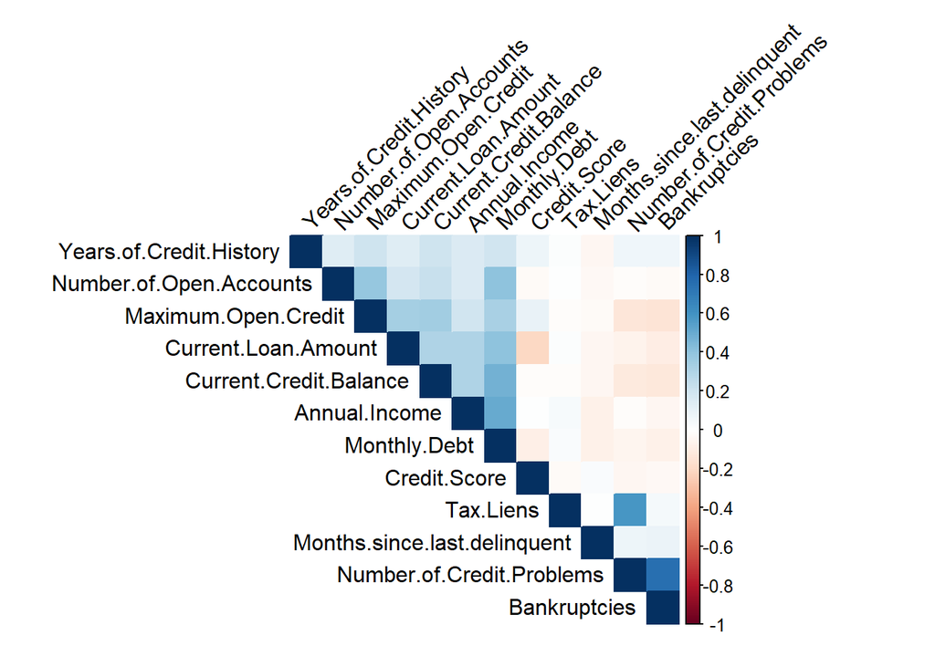

```r
#First, subset data to haev only numeric columns
numeric_df <- data %>%
  select_if(is.numeric)
#I will need to create a heat map
correlation_matrix <- cor(numeric_df)
corrplot(correlation_matrix, method = "color", type = "upper",
         order = "hclust", tl.col = "black", tl.srt = 45)
```

```r
print(correlation_matrix)
```

```
##                              Current.Loan.Amount Credit.Score Annual.Income
## Current.Loan.Amount                   1.00000000 -0.200180886   0.307348078
## Credit.Score                         -0.20018089  1.000000000   0.002368357
## Annual.Income                         0.30734808  0.002368357   1.000000000
## Monthly.Debt                          0.40196766 -0.080048128   0.505132945
## Years.of.Credit.History               0.13873744  0.072697616   0.155207100
## Months.since.last.delinquent         -0.04943098  0.026198861  -0.079631564
## Number.of.Open.Accounts               0.18449248 -0.026362552   0.159840859
## Number.of.Credit.Problems            -0.06853930 -0.044879122  -0.019992668
## Current.Credit.Balance                0.30267608 -0.011818733   0.307786064
## Maximum.Open.Credit                   0.33598167  0.092596074   0.196711023
## Bankruptcies                         -0.09167465 -0.032102296  -0.048148951
## Tax.Liens                             0.01796462 -0.020496656   0.036357132
##                              Monthly.Debt Years.of.Credit.History
## Current.Loan.Amount            0.40196766              0.13873744
## Credit.Score                  -0.08004813              0.07269762
## Annual.Income                  0.50513295              0.15520710
## Monthly.Debt                   1.00000000              0.19612291
## Years.of.Credit.History        0.19612291              1.00000000
## Months.since.last.delinquent  -0.07474466             -0.04123986
## Number.of.Open.Accounts        0.40993957              0.13067213
## Number.of.Credit.Problems     -0.05421249              0.06209077
## Current.Credit.Balance         0.47746384              0.20931107
## Maximum.Open.Credit            0.32720777              0.20871554
## Bankruptcies                  -0.07849394              0.06607777
## Tax.Liens                      0.02136366              0.01864790
##                              Months.since.last.delinquent
## Current.Loan.Amount                          -0.049430982
## Credit.Score                                  0.026198861
## Annual.Income                                -0.079631564
## Monthly.Debt                                 -0.074744656
## Years.of.Credit.History                      -0.041239860
## Months.since.last.delinquent                  1.000000000
## Number.of.Open.Accounts                      -0.034262415
## Number.of.Credit.Problems                     0.070928880
## Current.Credit.Balance                       -0.041181631
## Maximum.Open.Credit                          -0.028575415
## Bankruptcies                                  0.081255285
## Tax.Liens                                     0.006254317
##                              Number.of.Open.Accounts Number.of.Credit.Problems
```

[output cut: 23 more lines]

```
## Bankruptcies                            -0.12202577         -0.14412783
## Tax.Liens                               -0.01491616         -0.01745130
##                              Bankruptcies    Tax.Liens
## Current.Loan.Amount           -0.09167465  0.017964623
## Credit.Score                  -0.03210230 -0.020496656
## Annual.Income                 -0.04814895  0.036357132
## Monthly.Debt                  -0.07849394  0.021363659
## Years.of.Credit.History        0.06607777  0.018647898
## Months.since.last.delinquent   0.08125528  0.006254317
## Number.of.Open.Accounts       -0.02510651  0.006537543
## Number.of.Credit.Problems      0.75307702  0.581318457
## Current.Credit.Balance        -0.12202577 -0.014916156
## Maximum.Open.Credit           -0.14412783 -0.017451302
## Bankruptcies                   1.00000000  0.046343757
## Tax.Liens                      0.04634376  1.000000000
```